# Anthony Botello

## Lab 4, PHYS 434 AD

```python
%matplotlib inline
import matplotlib
import matplotlib.pyplot as plt
plt.rcParams['figure.figsize'] = (20,10)

import numpy as np
import pandas as pd
import h5py

import scipy
from scipy import stats
from scipy.signal import fftconvolve as convolve
```

```python
hf = h5py.File('gammaray_lab4.h5','r')
data = np.array(hf.get('data'))
hf.close()
```

```python
df = pd.DataFrame(data).T
df.columns = ['Time (GPS sec)','Solar Phase (deg)','Earth Longitude (deg)','Counts']
df
```

|  | Time (GPS sec) | Solar Phase (deg) | Earth Longitude (deg) | Counts |
| --- | --- | --- | --- | --- |
| 0 | 940680016.0 | 315.000000 | 45.000000 | 10.0 |
| 1 | 940680016.1 | 315.007112 | 45.006667 | 8.0 |
| 2 | 940680016.2 | 315.014225 | 45.013333 | 7.0 |
| 3 | 940680016.3 | 315.021337 | 45.020000 | 11.0 |
| 4 | 940680016.4 | 315.028449 | 45.026667 | 8.0 |
| ... | ... | ... | ... | ... |
| 25919996 | 943272015.6 | 345.304884 | 44.973333 | 5.0 |
| 25919997 | 943272015.7 | 345.311996 | 44.980000 | 9.0 |
| 25919998 | 943272015.8 | 345.319109 | 44.986667 | 8.0 |
| 25919999 | 943272015.9 | 345.326221 | 44.993333 | 11.0 |
| 25920000 | 943272016.0 | 345.333333 | 45.000000 | 12.0 |

25920001 rows × 4 columns

# Problem 1

## 1)

We are analyzing data from a satellite in a low Earth, 90 minute orbit that records the number of gamma rays it detects in a 100 ms interval. For each measurement, the metadata (see table above) gives us the GPS time, the position of the sun relative to the orbit, and the position of the satellite relative to the Earth. Since the data set consists of over 25 million data points, it would be impractical to try to discern anything about the cosmic ray background by looking at the entire set as a whole. However, we can use the fact that the satellite's orbit is periodic to partition the data set by orbital period. (The plot below of gamma ray counts vs. time demonstrates the periodic nature of the data.)

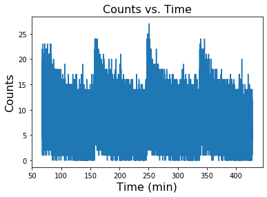

```python
time = data[0,:].copy()
time = time - time[0]

fig,ax = plt.subplots(1,1)
ax.plot(time[40500:(94500 + 162000)]/60,data[3,40500:(94500 + 162000)])
ax.set_xlabel('Time (min)',fontsize=16)
ax.set_ylabel('Counts',fontsize=16)
ax.set_title('Counts vs. Time',fontsize=16)
plt.show()
```

## 2)

Since the satellite is in a 90 minute orbit, we can analyze the background by averaging over all of the orbits. Below we've plotted how the average gamma-ray counts changes as the satellite progresses through its orbit. We can see that the number of counts drops off exponentially as a function of time. We've also calculated the standard deviation of the number of counts at each point in the orbit by partitioning the entire data set into 54,000 individual sets of about 480 elements since the satellite takes 54,000 measurements in each orbit and there are about 480 orbits total. Doing so, we found that the standard deviation also drops off exponentiall as a function of time.

```python
avg_counts = data[3,40500:94500].copy()
part = data[3,40500:25906500].copy()
part = np.vstack(np.split(part,479))

periods = 1
for i in range(1,479):
    avg_counts += data[3,(40500 + i*54000):(94500 + i*54000)]
    periods += 1
avg_counts = avg_counts/480

std = []
for i in range(54000):
    std.append(part[:,i].std())

period = time[40500:94500]/60
period = period - period[0]

A_1 = (max(avg_counts[0:300]) + min(avg_counts[0:300]))/2 - (max(avg_counts[53700:54000]) + min(avg_counts[53700:54000]))/2
b_1 = -np.log((1/np.power(10,0))/A_1)/90
C_1 = (max(avg_counts[53700:54000]) + min(avg_counts[53700:54000]))/2

A_2 = (max(std[0:300]) + min(std[0:300]))/2 - (max(std[53700:54000]) + min(std[53700:54000]))/2
b_2 = b_1 = -np.log((1/np.power(10,1))/A_2)/90
C_2 = (max(std[53700:54000]) + min(std[53700:54000]))/2
```

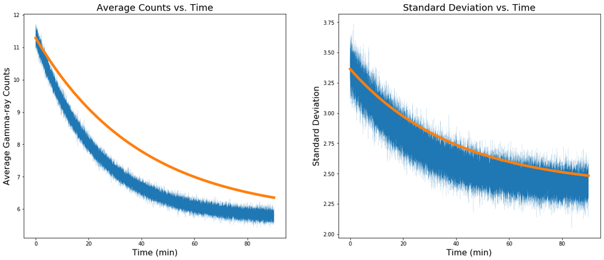

```python
fig,ax = plt.subplots(1,2,figsize=(20,8))

ax[0].plot(period,avg_counts,linewidth=0.1)
ax[0].set_title('Average Counts vs. Time',fontsize=18)
ax[0].set_xlabel('Time (min)',fontsize=16)
ax[0].set_ylabel('Average Gamma-ray Counts',fontsize=16)
ax[0].plot(period,A_1*np.exp(-period*b_1) + C_1,linewidth=5)

ax[1].plot(period,std,linewidth=0.1)
ax[1].set_title('Standard Deviation vs. Time',fontsize=18)
ax[1].set_xlabel('Time (min)',fontsize=16)
ax[1].set_ylabel('Standard Deviation',fontsize=16)
ax[1].plot(period,A_2*np.exp(-period*b_2) + C_2,linewidth=5)

plt.show()
```

## 3)

We were unable to perfectly model the background in time (see plots above). However, we suspect that the PDF of the background as a function of time would be a Gaussian function $N(x,t;\mu(t),\sigma^2(t))$ where $\mu(t) = A_\mu e^{-b_\mu t} + C_\mu$ and $\sigma^2(t) = \left[A_\sigma e^{-b_\sigma t} + C_\sigma\right]^2$. The reason we believe it is Gaussian is because of the plots below.

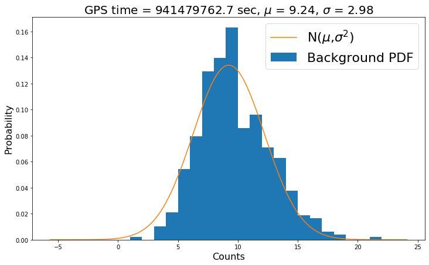

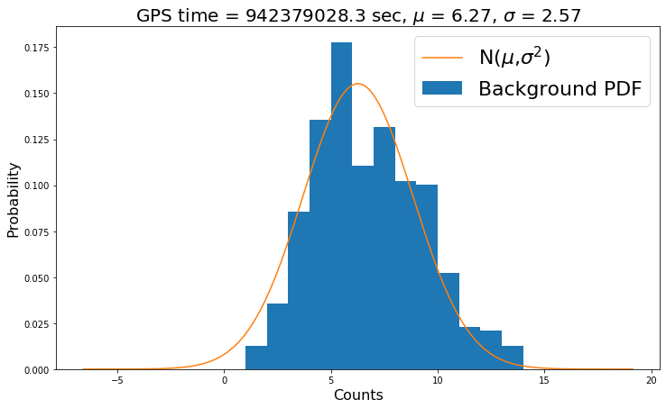

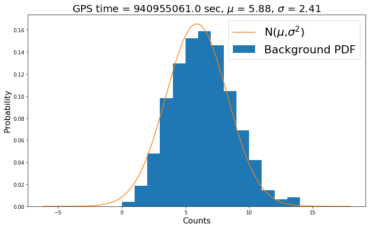

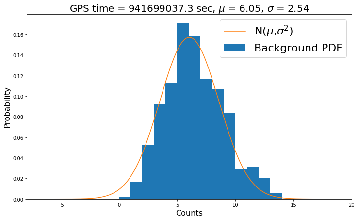

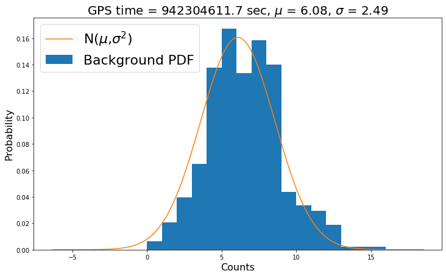

```python
mod = np.remainder
t_0 = data[0,0]
def plot_random_time():
    t = np.round(time[np.random.randint(0,len(time))],decimals=1)
    gps = t_0 + t
    secs = int(mod(round(t * 10),54000))
    counts = part[:,secs]
    mu = counts.mean()
    sigma = counts.std()
    bins = int(max(counts) - min(counts))
    x = np.linspace(mu - 5*sigma, mu + 5*sigma,10000)
    gauss = stats.norm(loc=mu,scale=sigma)

    fig,ax = plt.subplots(1,1,figsize=(12,7))
    ax.hist(counts,bins=bins,density=True,label='Background PDF')
    ax.plot(x,gauss.pdf(x),label='N($\mu$,$\sigma^2$)')
    ax.set_ylabel('Probability',fontsize=16)
    ax.set_xlabel('Counts',fontsize=16)
    ax.set_title(f'GPS time = {gps} sec, $\mu$ = {np.round(mu,decimals=2)}, $\sigma$ = {np.round(sigma,decimals=2)}',fontsize=20)
    ax.legend(fontsize=22)
    plt.show()

for i in range(5):
    plot_random_time()
```

Above we have plotted the probability distribution of the number of counts at random times based on the phase of the satellite's orbit as well as a Gaussian PDF with the same $\mu$ and $\sigma$ as the background PDF. These graphs demonstrate that the background distribution is Gaussian with time-dependent parameters. The for of the time dependence of $\mu(t)$ and $\sigma^2$ follows from the results of 2).

## 4)

Since the background PDF evolves in time, the discovery threshold should also evolve in time. Below we have defined a function to calculate the $5\sigma$ threshold at random times based on the standard deviation of the Gaussian-distributed background at that time.

```python
def random_time_5_sigma():
    t = np.round(time[np.random.randint(0,len(time))],decimals=1)
    gps = t_0 + t
    secs = int(mod(round(t * 10),54000))
    counts = part[:,secs]
    mu = counts.mean()
    sigma = counts.std()
    print(f'GPS Time: {gps}, \'5-sigma\': {np.round(5*sigma,decimals=3)}')

for i in range(5):
    random_time_5_sigma()
```

```
GPS Time: 941856632.3, '5-sigma': 12.382
GPS Time: 940859124.2, '5-sigma': 13.767
GPS Time: 941429594.2, '5-sigma': 11.592
GPS Time: 942136025.7, '5-sigma': 12.707
GPS Time: 942439771.6, '5-sigma': 11.782
```

# Problem 2

## 1)

```python
hf1 = h5py.File('images.h5','r')
img = np.array(hf1.get('image1'))
hf1.close()
```

```python
pd.DataFrame(img)
```

|  | 0 | 1 | 2 | 3 | 4 | 5 | 6 | 7 | 8 | 9 | ... | 190 | 191 | 192 | 193 | 194 | 195 | 196 | 197 | 198 | 199 |
| --- | --- | --- | --- | --- | --- | --- | --- | --- | --- | --- | --- | --- | --- | --- | --- | --- | --- | --- | --- | --- | --- |
| 0 | -1.247111 | -0.186197 | 0.448365 | -0.247630 | -0.090217 | 0.079884 | 0.192235 | -0.424249 | -0.443930 | 0.231892 | ... | 0.620815 | 1.361076 | -0.886600 | 0.896633 | 0.243773 | 0.157816 | 0.226621 | -0.573971 | -0.021710 | -0.156363 |
| 1 | 0.097275 | 0.209346 | 0.055072 | 0.688360 | 0.311118 | 0.740495 | 0.043384 | -0.209899 | 0.633605 | 0.972805 | ... | 0.676014 | -0.703822 | -0.263644 | 0.479644 | 0.119873 | 0.705886 | 0.514408 | -0.266296 | -0.974399 | -0.726714 |
| 2 | 0.339004 | -0.212084 | -0.532166 | -0.316361 | -0.125275 | -0.773448 | 0.663428 | 0.863105 | -0.665504 | -0.526011 | ... | -0.546350 | -0.097670 | 0.119766 | -1.146073 | -0.186311 | 0.120980 | -0.177180 | -1.005019 | 0.244867 | 0.042350 |
| 3 | 0.295583 | 0.159522 | -0.749740 | 0.832371 | 0.577139 | 0.549850 | -0.623062 | -0.136001 | -0.371542 | -0.244525 | ... | -0.314221 | 1.204621 | -0.164202 | 0.391252 | -1.001139 | 0.292682 | -0.014183 | 0.439823 | 0.304720 | -0.312269 |
| 4 | 1.913686 | 0.390810 | -0.439352 | 0.902434 | -0.350572 | 0.595645 | -0.184644 | 0.134626 | 0.811984 | 0.068902 | ... | 0.347667 | 0.219449 | -0.836648 | 0.244172 | 0.824907 | 0.925146 | -0.830645 | -0.712753 | -0.703343 | 0.118671 |
| ... | ... | ... | ... | ... | ... | ... | ... | ... | ... | ... | ... | ... | ... | ... | ... | ... | ... | ... | ... | ... | ... |
| 195 | -0.037789 | 0.656157 | 0.575827 | -0.166552 | -0.429860 | -0.332520 | 0.780510 | 0.060165 | 0.485538 | 0.938139 | ... | 0.362768 | 0.809036 | -0.244707 | -0.020250 | -0.355403 | -1.029744 | 1.071153 | -0.039276 | 0.581919 | 0.785217 |
| 196 | -0.210000 | 0.477316 | 0.599573 | -0.662800 | 0.139502 | -0.760184 | 0.508111 | -0.600438 | 0.368480 | 0.906956 | ... | -0.184078 | 1.080374 | 0.797662 | 0.060978 | -0.220786 | -1.037933 | -1.582755 | -0.330266 | 1.346453 | 0.162640 |
| 197 | 0.556671 | -0.470455 | -0.016169 | 0.681320 | 0.625595 | -0.155577 | -0.665809 | -0.793341 | -0.962934 | -0.535169 | ... | -0.421681 | 0.437295 | 0.515797 | -0.041418 | 0.043160 | 0.288504 | -0.693003 | 0.624305 | -0.164835 | -0.247751 |
| 198 | -0.320549 | -0.213482 | 0.402981 | 0.170565 | -0.035045 | -0.620778 | -0.065461 | 1.182951 | -0.352472 | -0.227369 | ... | 0.053328 | -0.594970 | 0.155068 | -0.131334 | 0.378117 | -1.426596 | -0.648230 | -0.689573 | -0.474598 | 0.318455 |
| 199 | 1.162707 | -0.569646 | -0.175267 | -1.136357 | -0.062063 | -0.665650 | 0.548649 | 0.638627 | -1.028123 | 0.105884 | ... | -0.023433 | -0.337067 | -0.226151 | -0.544171 | 0.337843 | -0.311711 | 0.059706 | 0.456208 | -0.344487 | 0.251347 |

200 rows × 200 columns

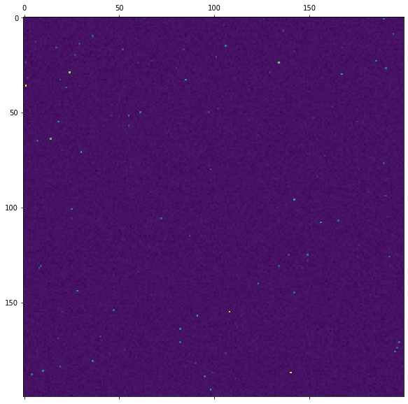

```python
fig,ax = plt.subplots(1,1,figsize=(10,10))
ax.matshow(img)

plt.show()
```

## 2)